# Elfin Chain Selection

DC

2024-08-05

# ChainSelection

There are 14 chains having more than 30 games. Too many games on a chain meaning we will not get any support from the officials. So we need to further look at smaller chains.

10 chains have less than 500 games, among them, only Base & Arb1 and Blast are EVMs that we can deploy without much fuss.

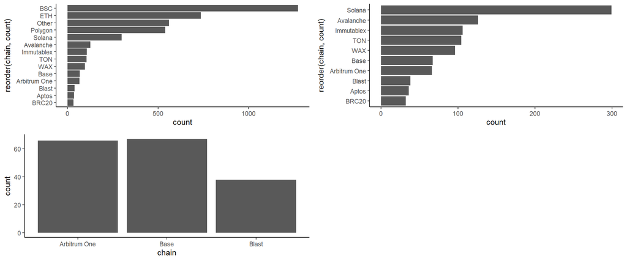

# Topgame on ARB BLAST BASE

Blast has some games, but has not been doing well after the TGE, espcially considering Ultiverse has been doing poorly on it, this chain might not be kind to cross-chain new players. The best game, Cambria, was receiving BLAST gold for their players, whereas Crypto Valleys also received BLAST gold, but yet to perform. Given the Blast TGE has been terrible, this is not an ideal chain for new comers.

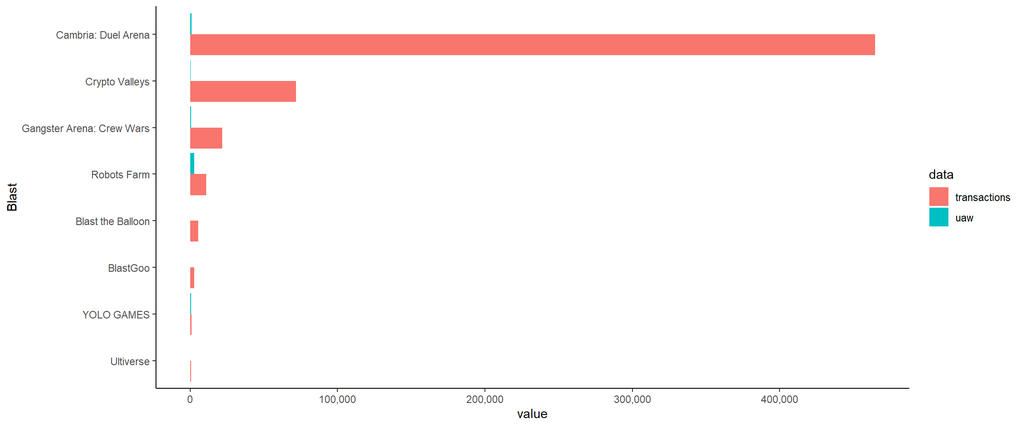

There are some games doing great numbers on ARB and BASE, both has great on-chain acitivities. While both have great UAW, BASE games, in general, have more on-chain transactions. At the sametime, BASE has a much more vibrant meme culture where some the total meme coins marketcap is at 1billion with over 270+million daily trading value. It is a much better chain for Gamefi deployment.

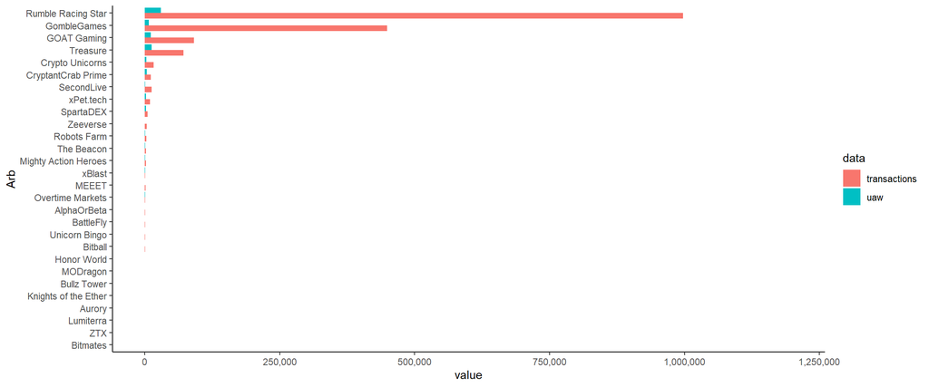

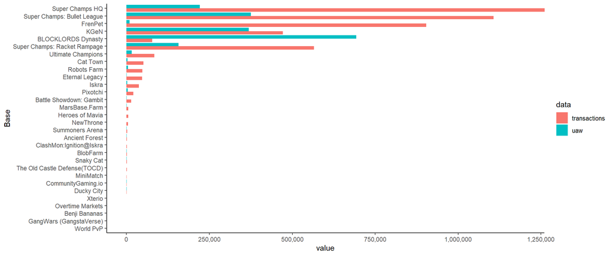

# BlockLord User activity

Why are these games so popular on Base? We further looked into Blocklords on-chain activities.

The key is account abstraction.

Blocklord has two major in-game activities corresponding to two contract addresses:

- x017405a2de0613e12cd3d7b67e691bfefc46debf - mission
- 0x80625310Db240631A91f61659CCC550eA9761742 - duel

Here is a typical tx demonstrating how things are logged on-chain

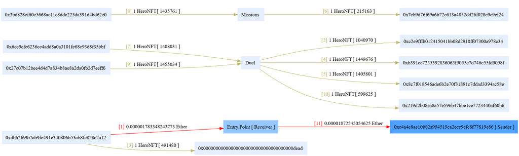

Here is how Blocklords active user, new user evolve over time. We identify those who completed daily quests, either mission or duel as active user.

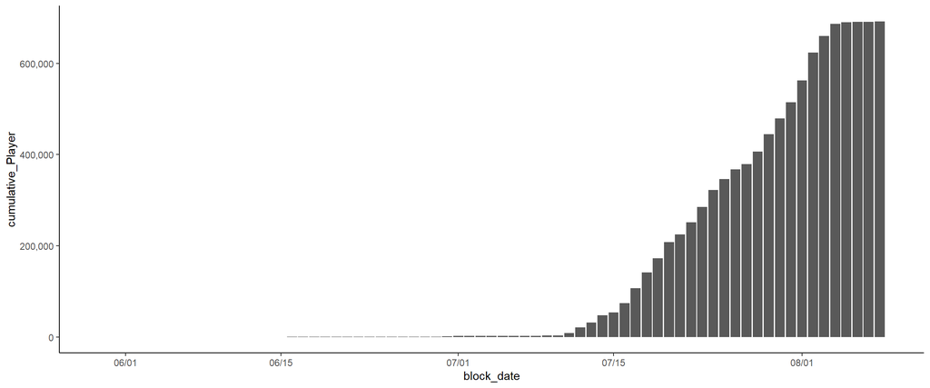

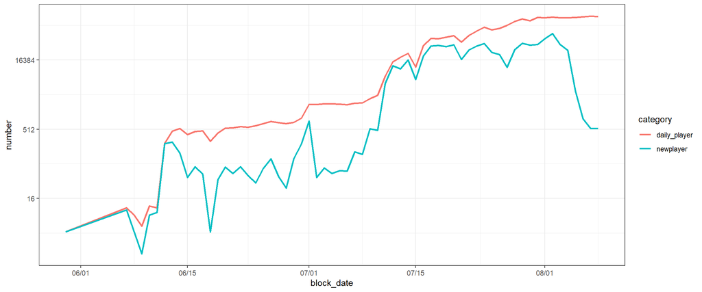

# Rumble Racing Star User activity

Now let us look at the top game on Arbitrum - Rumble Racing Star by Delabs

Here we use the daily spin to qualify for daily player, since player can only do spins after fulfilling these criteria

- Run 1 race on RRS
- Hold and AP or MB NFT
- Send Message on Telegram chat for Jambo

RRS does not use AA wallets, meaning all these wallets are active Web3 players, much better aligned with our goal.

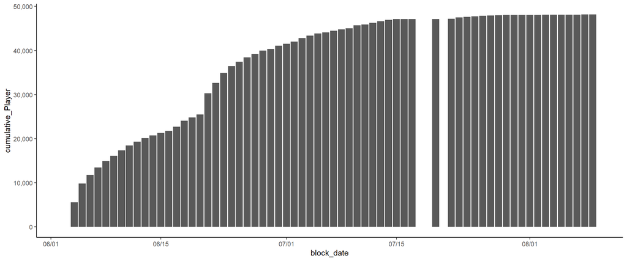

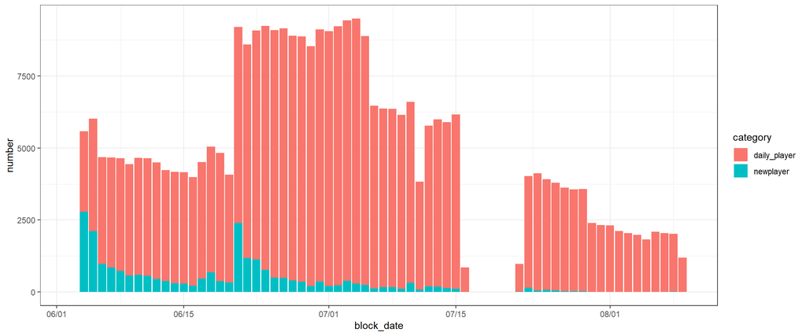

# Base game not using AA

Let us go back to base games that are not using AA wallets - Cat Town

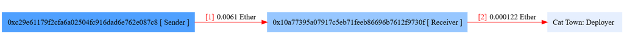

The Numbers are certain much smaller than games using AA wallets, nor can it reach the level of top games on ARB, but are still not bad. They are still having over 1000 daily players.

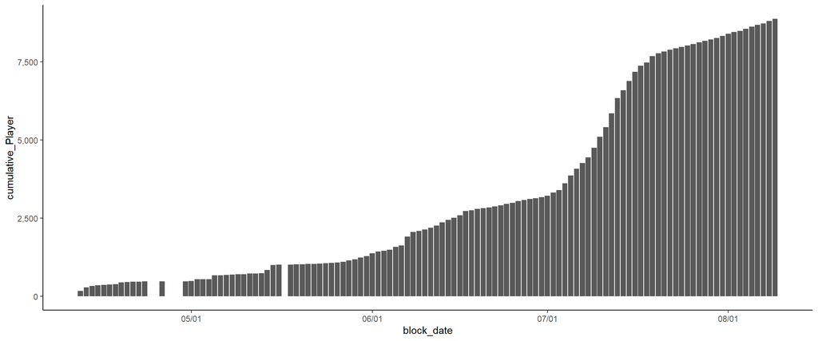

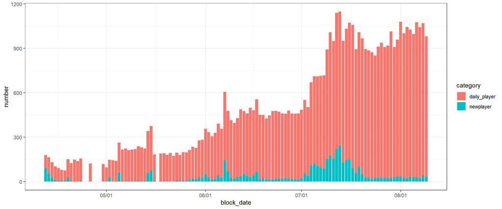